# Swiss TPH Quarto training

Analytically reproducible documents

Authors

Affiliation

Hélène Langet

Swiss TPH Research-IT

Zhihan Zhu

Swiss TPH Research-IT

Published

January 16, 2026

## 1 Learning objectives 🎯

This training introduces the purpose and benefits of creating **analytically reproducible documents** and shows how [**Quarto**](https://quarto.org/) can facilitate this process:

- Understand the concept of analytically reproducible documents, including their benefits for public health research;
- Understand where Quarto fits within the landscape of existing tools and the advantages it offers over other technical solutions;
- Learn the basics of the Quarto syntax;
- Gain hands-on experience using Quarto with RStudio to create dynamic, reproducible documents  
  e.g., analytical reports, research manuscripts, websites, dashboards, etc.

[figure not shown]

## 2 Pre-requisites 📋

- Basic knowledge of R programming
- Familiarity with the RStudio interface
- Laptop with RStudio version 2022.07 or later installed

## 3 Content navigation 🧭

In this training, you will find the following resources to help you along your learning journey:

- 📘 **Lecture notes** — Reference materials and examples;
- 📙 **Assignments** — Self-paced exercises to practice and apply skills:
  - 📋 **Instructions** — Objectives and expectations of the exercise;
  - ✅ **Corrections** — Detailed solutions with step-by-step explanations;
  - Difficulty of assignments:
    - *Getting started* 🌱 — Guided exercises for complete beginners;
    - *Beginner* ⭐ – Foundational exercises to build confidence;
    - *Intermediate* ⭐⭐ – Intermediate challenges to build on core concepts for deeper understanding;
    - *Advanced* ⭐⭐⭐ – More challenging exercises for comprehensive mastery.

## 4 Feedback 💬

We value your input! The fastest way to share your feedback and help us improve this training is by using *Hypothesis*. When providing feedback, please aim to be *constructive* and *specific*.

1. If you are new to Hypothesis, create an [Hypothesis](https://hypothes.is/signup) account;
2. Activate Hypothesis by clicking the left arrow icon `>` in the top right corner of the pages of this website to open the Hypothesis annotation sidebar, and log in;

[figure not shown]

3. select the text you want to comment.

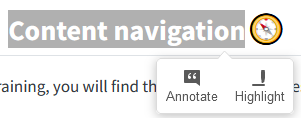

## 5 Update history 📜

- February 04, 2025: Initial release.
- January 16, 2026: Add instructions to use Swiss TPH templates.

## 6 Contributors 👥

This work was a collaborative effort, incorporating feedback from students and staff at Swiss TPH. Substantial contributions are acknowledged where applicable on the corresponding pages.

## 7 License 🏷️

This content is licensed under a [Attribution 4.0 International (CC BY 4.0)](https://creativecommons.org/licenses/by/4.0/).

You are free to:

- Share — copy and redistribute the material in any medium or format.
- Adapt — remix, transform, and build upon the material for any purpose, even commercially.

Under the following terms:

- Attribution — You must give appropriate credit, provide a link to the license, and indicate if changes were made. You may do so in any reasonable manner, but not in any way that suggests the licensor endorses you or your use.
- No additional restrictions — You may not apply legal terms or technological measures that legally restrict others from doing anything the license permits.